# Projet Statistiques Multidimentionnelles/ACP

# 1. Introduction

On manipule un jeu de données extrait d’une base de données de composition alimentaire de plats préparés, biscuits, compotes, confiseries, boissons… Celui-ci comporte 362 lignes et 13 colonnes. Le fichier RData « data.baby.RData » contient 2 tables, la première contenant les noms des plats ainsi que d’autres variables, l’autre table étant formée des variables numériques seulement.

Nous ferons une l’Analyse en Composantes Principales (ACP) du jeu de données complètes, ou d’une extraction de ce jeu de données. Une extraction signifie que certains individus ou certaines variables seront mises en «inactifs ». On cherche à comprendre ce qui caractérise la variabilité des plats et les différents types d’aliments, en se focalisant sur les vitamines.

## a) Pourquoi faut-il faire une ACP normée ?

Il faut faire une ACP normée sur ces données car elles n’ont pas les mêmes unités. En effet, certaines sont en milligrammes (’_mg’), d’autres en grammes (’_g’) et encore d’autres en microgrammes (’_mcg’).

## b) Application d’une ACP non normée

On charge les données du fichier “data.baby.RData” ainsi que les packages que nous allons utiliser au cours de l’analyse des données.

On performe une ACP non normée sur les données de ‘data.baby2.comp’.

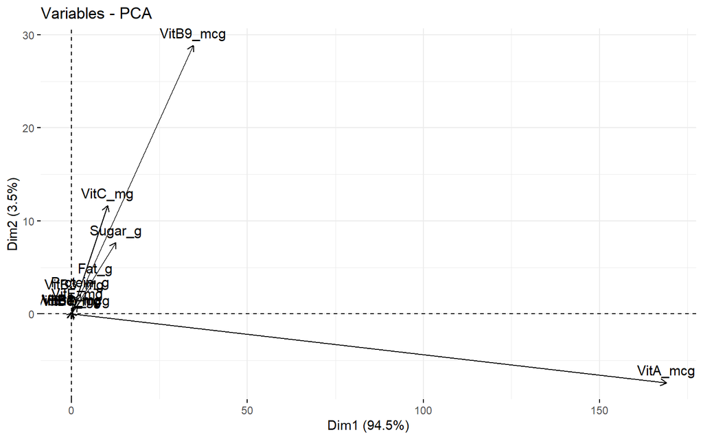

```r
pca.baby <- PCA(data.baby2.comp, scale.unit = FALSE, graph=FALSE)
fviz_pca_var(pca.baby)
```

Le graphique ci-dessus nous montre que l’axe un est principalement porté par ‘VitA_mcg’ et que 94.5% de l’inertie est représentée par l’axe 1. On pourrait penser que cela est une bonne chose, mais ça ne l’est pas car la variable ‘VitA_mcg’ est la variable qui a la plus grande variance (dû à son unité qui est en mcg) et elle a donc logiquement une contribution plus importante. Cela est dû à l’unité de mesure. Pour contourner ce problème, il faudrait réaliser une ACP normée et donc centrer et réduire les données.

Nous effectuons maintenant une ACP normée du jeu de données complet (les 13 variables numériques et les 362 plats).

# 2. Analyse des variables

## a) Matrice de corrélation

Tout d’abord, nous allons observer la matrice de corrélations entre les 13 variables de notre jeu de données ‘data.baby2.comp’. Pour la visualiser avec la fonction `corrplot(cor(data.baby2.comp))`, nous n’avons pas besoin de centrer et réduire manuellement les données de ‘data.baby2.comp’ car les corrélations entre les variables reste identique. La matrice des corrélations R vaut $Z^T * N * Z$, où Z est la matrice des données centrés réduites et N une matrice diagonale avec comme valeur 1/n sur sa diagonale (n le nombre d’observations du jeu de données).

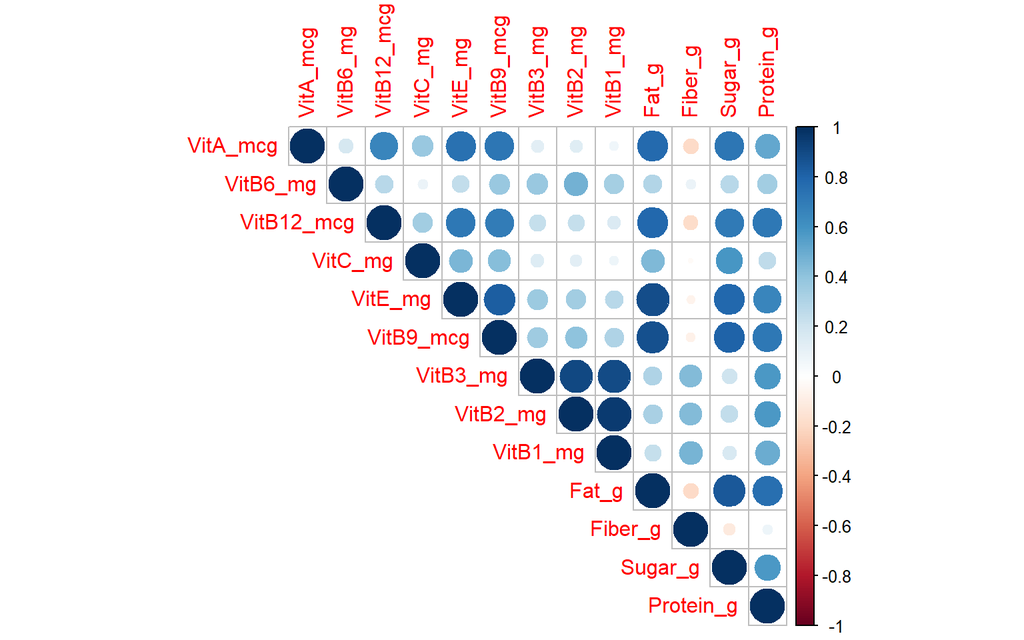

```r
corrplot(cor(data.baby2.comp),type="upper")
```

Nous pouvons observer que peu, voire aucune variable n’est corrélée négativement avec une autre. Cela implique qu’une variable va soit avoir une influence positive sur une autre variable, soit aucune. Par exemple, ‘VitA_mcg’ est fortement corrélée avec ‘VitB12_mg’, ‘VitE_mg’, ‘VitB9_mg’, ‘Fat_g’, ‘Sugar_g’ et ‘Protein_g’. Ainsi, plus un plat est composé de Vitamine A, plus il sera aussi composé de Vitamine B12, B9 et E, de graisses, de sucres et de protéines. Également, nous observons que ‘Protein_g’ possède des corrélations positives importantes (>0.5) avec les vitamines A, B12, E, B9 ainsi qu’avec ‘Fat_g’ et ‘Sugar_g’. Cela indique qu’un plat pour nourrisson contenant des protéines sera plus susceptible de contenir l’une de ces vitamines ou des graisses ou du sucre. Par contre, nous pouvons remarquer que ‘Fiber_g’ n’est que peu corrélée avec le reste des variables. La teneur en fibres d’un plat ne semble alors pas liée à sa composition en vitamines ou à sa composition nutritionnelle (graisses, sucre, protéines).

## b) Éboulis des valeurs propres

Nous allons observer l’éboulis des valeurs propres de la matrice des données centrée réduite. Tout d’abord nous allons regarder le tableau des valeurs propres :

```r
pca.normee <- PCA(data.baby2.comp, scale.unit=TRUE, graph=FALSE)
eig <- get_eigenvalue(pca.normee)
eig
```

```
##        eigenvalue variance.percent cumulative.variance.percent
## Dim.1  6.40347760       49.2575200                    49.25752
## Dim.2  2.93537473       22.5798056                    71.83733
## Dim.3  0.92384880        7.1065293                    78.94385
## Dim.4  0.75324419        5.7941861                    84.73804
## Dim.5  0.56340697        4.3338998                    89.07194
## Dim.6  0.41500607        3.1923544                    92.26430
## Dim.7  0.26438168        2.0337052                    94.29800
## Dim.8  0.21295069        1.6380823                    95.93608
## Dim.9  0.19777630        1.5213562                    97.45744
## Dim.10 0.14097388        1.0844145                    98.54185
## Dim.11 0.09549263        0.7345587                    99.27641
## Dim.12 0.06433777        0.4949059                    99.77132
## Dim.13 0.02972868        0.2286822                   100.00000
```

La première colonne renvoie les valeurs propres de R * M, R étant la matrice de corrélations et M étant notre métrique (ici la métrique identité de $\mathbb{R}^{13}$).

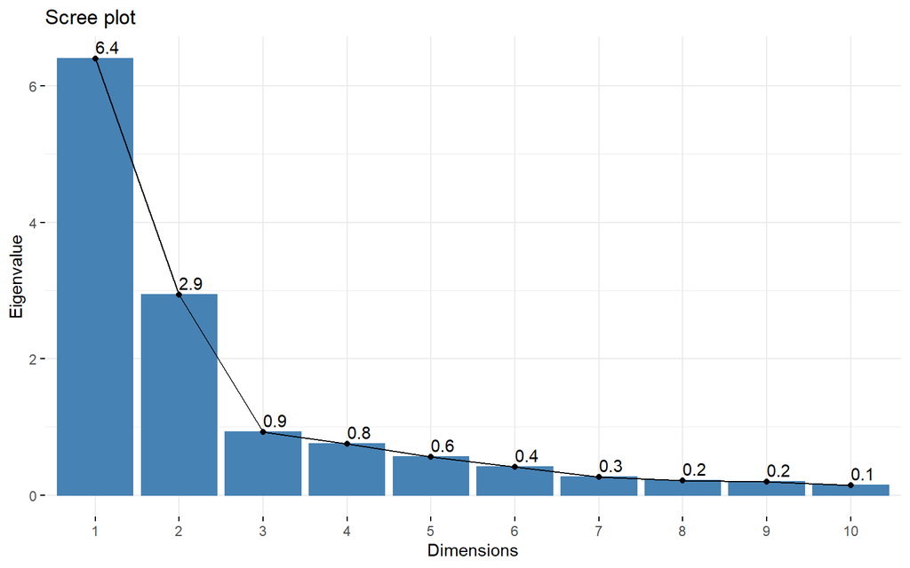

```r
fviz_eig(pca.normee, choice = "eigenvalue", addlabels=TRUE)
```

D’après le tableau des valeurs propres, nous observons que la majorité de l’information est portée par les deux premières dimensions. En regardant les deux autres colonnes du tableaux (variance portée par chaque dimension et variances cumulées), cela se confirme. Les deux premières dimensions portent environ 71% de l’inertie. D’après la règle de Kaiser et du fait que nous sommes en ACP normée, nous ne devons garder que les valeurs propres supérieures ou égales à 1. Ici nous ne devrions donc conserver que les 2 premières dimensions.

## c) Interprétation des 4 premières dimensions

Ici nous allons considérer les 4 premiers axes du fait que 0.9 et 0.8 sont des valeurs proches de 1. Concentrons nous d’abord sur les deux premiers axes :

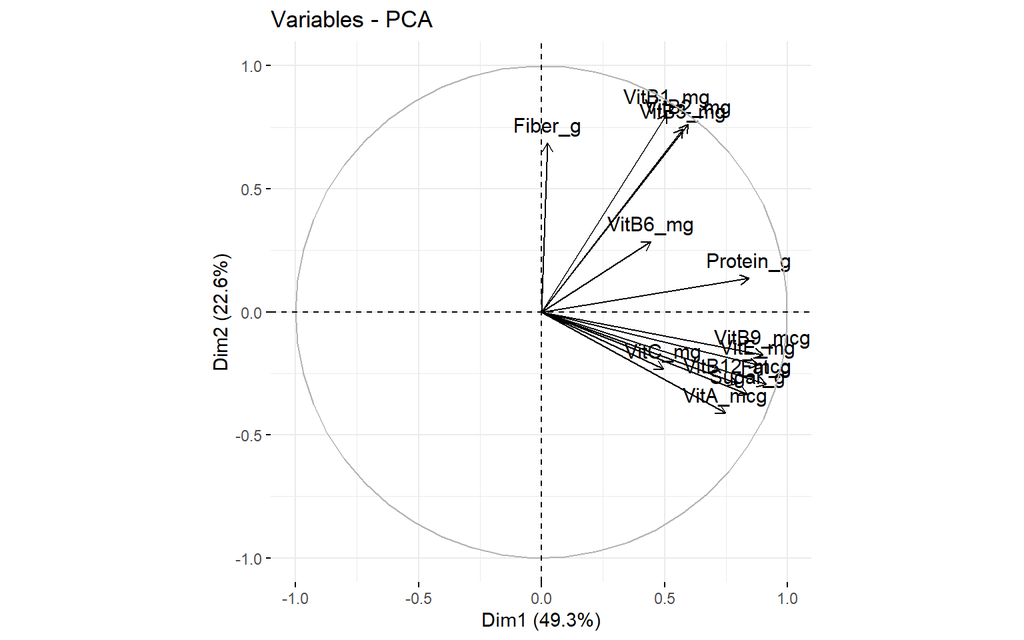

```r
fviz_pca_var(pca.normee,choice="var",axes = c(1,2))
```

Nous pouvons observer sur le cercle des corrélations ci-dessus que globalement toutes les variables sont bien projetées à l’exception de ‘VitC’ et de ‘VitB6’. Ainsi, les qualités de projections sont correctes donc les angles visibles sont fidèles aux angles réels qui sont le reflet des corrélations. Deux groupes de variables se dégagent, celles en haut à droite contenant ‘VitB1’ et celles en bas à droite contenant ‘VitB9’. Observons maintenant les dimensions 3 et 4 :

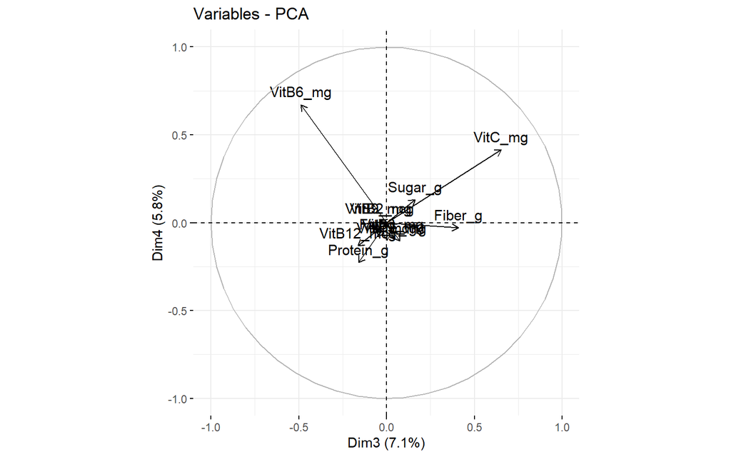

```r
fviz_pca_var(pca.normee,choice="var",axes = c(3,4))
```

C’est l’inverse ici. Globalement, toutes les variables sont mal projetées à l’exception de ‘VitB6’ et de ‘Vitc’. Ainsi, les qualités de projections sont correctes pour ces deux variables donc les angles visibles sont fidèles aux angles réels qui sont le reflet des corrélations. Ce plan factoriel est moins performant que le premier.

Regardons maintenant quelles sont les contributions de chaque variable sur les 4 premières dimensions. On sait que plus les contributions des variables à une dimension tendent à être toutes égales, meilleure est cette dimension.

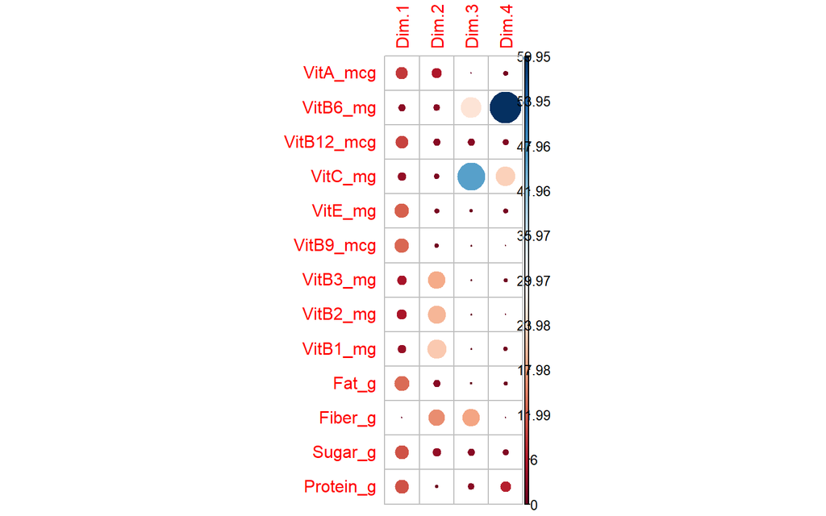

```r
var <- get_pca_var(pca.normee)
corrplot(var$contrib[,1:4], is.corr=FALSE)
```

Ainsi, sur le graphique ci-dessus qui représente les contributions des variables sur chaque axe, on observe que les deux premières dimensions représentent bien les variables en globalité alors que la dimension 3 représente plus ‘VitC’ et la dimension 4 représente plus ‘VitB6’.

# 3. Analyse des points-individus sur le premier plan factoriel

## a) Tableau des coordonnées factorielles des plats n°237, 218, 216, 144, 141, 140, 149, 340 et 125

```r
plats <- c(237,218,216,144,141,140,149,340,125)
ind <- get_pca_ind(pca.normee)
ind$coord[plats,1:2]
```

```
##         Dim.1      Dim.2
## 237 7.0927269 -1.5878814
## 218 7.1020900 -2.5066857
## 216 8.8310797 -1.8455244
## 144 6.0171830 10.2276548
## 141 1.8157564  0.6756085
## 140 0.9549053  3.8729800
## 149 0.4489068  0.7979775
## 340 0.5935591  4.2477724
## 125 3.5169843  8.7869979
```

## b) Position des plats 218 et 216

Les plats 218 et 216 semblent relativement proches car leurs coordonnées sur les deux premiers axes sont très proches. Ils doivent donc avoir des compositions nutritionnelles et des teneurs en vitamines similaires. On s’attend naturellement à retrouver ces deux plats dans la partie inférieure droite du cercle.

## c) Comparaison avec le plat 144

Le plat 144 a une coordonnée sur l’axe 1 équivalente aux plats 216 et 218 mais a une coordonnée qui leur est opposée sur l’axe 2. Cela vient du fait que le plat 144 possède une forte teneur en fibres alors que les deux autres (218 et 216) n’ont aucune teneur en fibres. On s’attend à retrouver le plat 144 dans la partie supérieure droite du cercle.

## d) Variance des abscisses des points

Désormais, on souhaite avoir la variance de l’abscisse des points. Une première façon de l’obtenir est de chercher la variance des points projetés. On sait que : $\psi^{\alpha} = \lambda_{\alpha}$. Or ici, nous avons deux axes donc $\alpha \in \{1,2\}$, d’où :

```r
var_psi1 <- pca.normee$eig[1,1] ; var_psi1
```

```
## [1] 6.403478
```

```r
var_psi2 <- pca.normee$eig[2,1] ; var_psi2
```

```
## [1] 2.935375
```

Sinon, on peut utiliser la formule de la variance pour obtenir le même résultat.

$$Var(\psi^{\alpha}) = \frac{1}{n} \sum_{i=1}^{n} (\psi_{i}^{\alpha})^2$$
Ainsi, après calcul, on obtient le résultat suivant.

```r
v_psi1_m2 <- 361/362*var(ind$coord[,1]) ; v_psi1_m2 # car var() donne la variance empirique corrigée (1/361) ; on multiplie par 361/362 pour avoir la variance empirique
```

```
## [1] 6.403478
```

```r
v_psi2_m2 <- 361/362*var(ind$coord[,2]) ; v_psi2_m2
```

```
## [1] 2.935375
```

## e) Les 20 plats les plus contribuants à la construction de l’axe 1, à la construction de l’axe2, à la construction du plan (1,2)

Nous allons étudier l’ensemble des plats du jeu de données à partir de maintenant. On réalise d’abord le diagramme en barre de la contribution des individus à l’axe 1, puis on affichera les 20 plats qui contribuent le plus à la formation de cette axe.

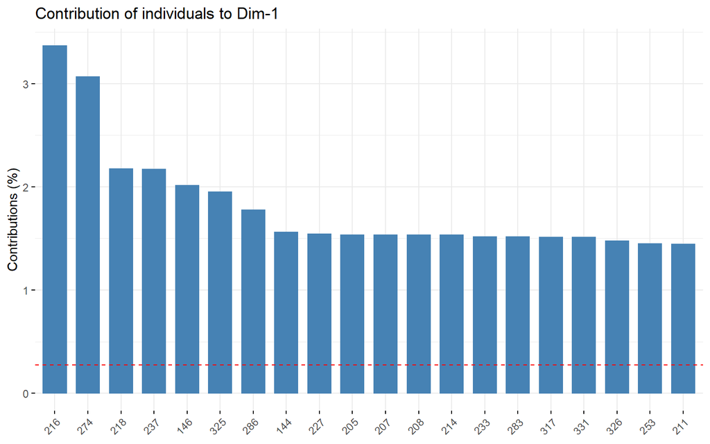

```r
fviz_contrib(pca.normee,choice="ind",axes=1, top=20)
```

Le diagramme montre des valeurs relativement homogènes. Les deux plus grands contributeurs ont une contribution aux alentours des 3%. Ensuite, du troisième au septième individu, la contribution est proche de 2%. En ce qui concerne les autres, on a une contribution stable aux alentours de 1.5%.

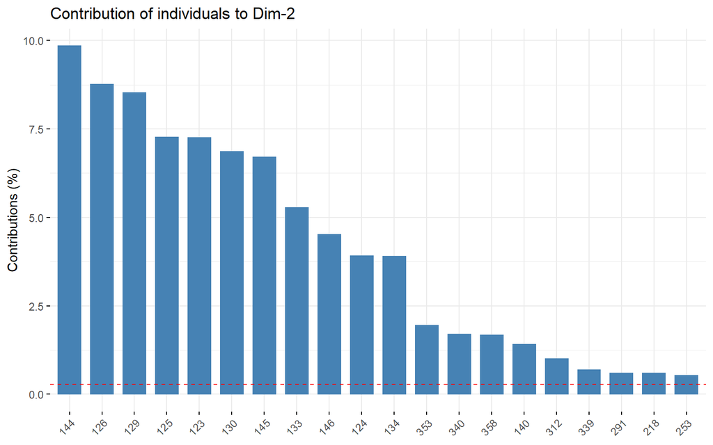

```r
fviz_contrib(pca.normee,choice="ind",axes=2, top=20)
```

Pour la dimension 2, on voit que les contributions ne sont absolument pas homogènes et décroient de manière quasi linéaire. Le plat 144 est celui qui y contribue le plus avec une représentation d’environ 10%. Cela doit venir du fait qu’il est une forte teneur en fibre.

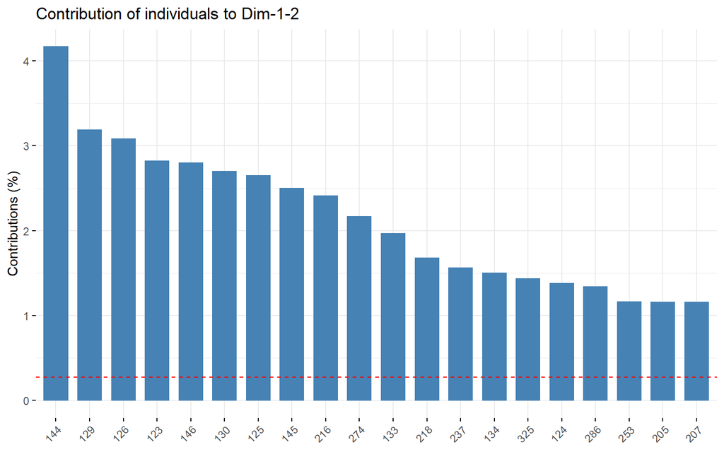

```r
fviz_contrib(pca.normee,choice="ind",axes=c(1,2), top=20)
```

Pour la contribution sur le premier plan factoriel, encore une fois on observe que celui qui y contribue le plus est le plat 144. La contribution de chaque plat diminue jusqu’au plat 218 de façon assez importante et ensuite se stabilise aux alentours des 1.5%. On retrouve bien les plats ayant les plus fortes contributions pour l’axe 1 et pour l’axe 2 en premier dans le graphique.

## f) Interprétation globale des positions des plats sur le deux premiers plans factoriels

On réalise maintenant le graphe des individus sur le premier plan factoriel.

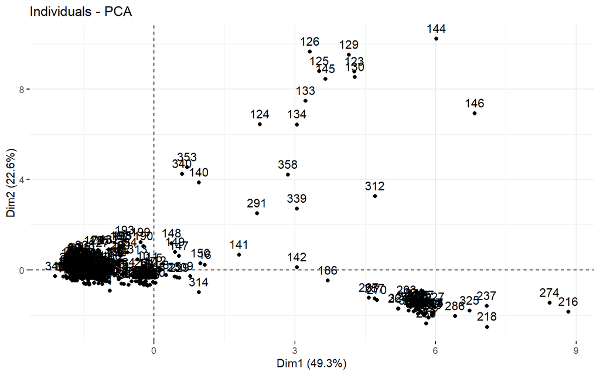

```r
fviz_pca_ind(pca.normee, axes = c(1,2))
```

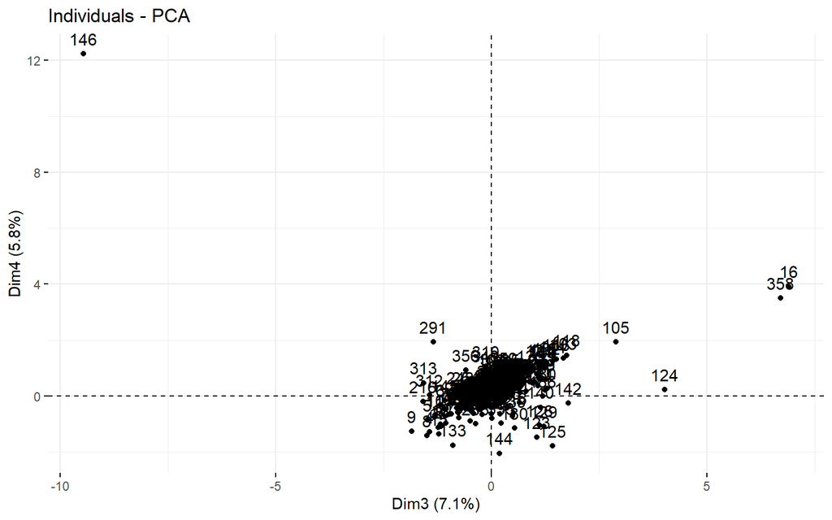

```r
fviz_pca_ind(pca.normee, axes = c(3,4))
```

# 4. Inactivation des variables Fat_g, Sugar_g, Protein_g, Fiber_g

Dans cette partie, on veut réaliser l’ACP normée sur notre jeu de données en mettant les variables ‘Fat’, ‘Sugar’, ‘Protein’ et ‘Fiber’ en variables supplémentaires. Ces variables ne seront pas prises en compte dans le calcul de l’ACP, mais elles seront présentes sur les graphes. Nous allons reprendrons les mêmes questions que précédemment.

## Analyse des variables

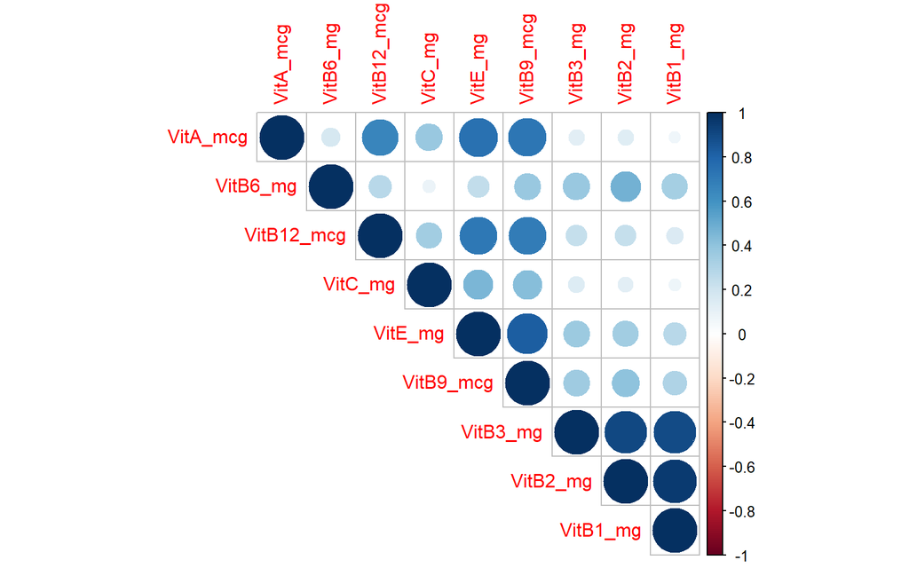

```r
corrplot(cor(data.baby2.comp[1:9]), type="upper")
```

La matrice de corrélation pour ce modèle est juste une sous matrice de la matrice de corrélation du 2.a), les valeurs restent les mêmes. On s’intéresse donc en premier lieu au graphe des éboulis des valeurs propres.

```r
pca.r <- PCA(data.baby2.comp, scale.unit=TRUE, graph=FALSE, quanti.sup=c(10:13))
pca.r$eig
```

```
##        eigenvalue percentage of variance cumulative percentage of variance
## comp 1 4.31486191             47.9429101                          47.94291
## comp 2 2.27545397             25.2828219                          73.22573
## comp 3 0.82354105              9.1504561                          82.37619
## comp 4 0.69032682              7.6702980                          90.04649
## comp 5 0.34407313              3.8230348                          93.86952
## comp 6 0.23983514              2.6648349                          96.53436
## comp 7 0.17710217              1.9678019                          98.50216
## comp 8 0.10407700              1.1564111                          99.65857
## comp 9 0.03072882              0.3414314                         100.00000
```

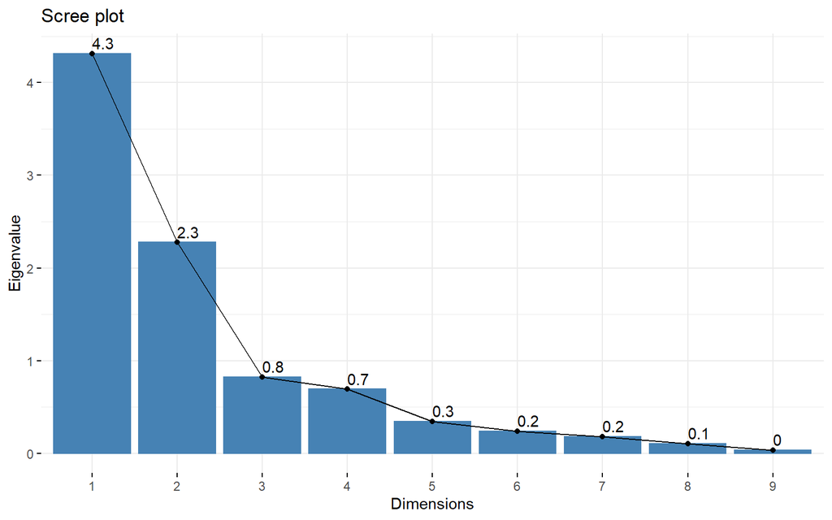

```r
fviz_eig(pca.r, choice = "eigenvalue", addlabels=TRUE)
```

On voit que les dimensions qui conservent le plus de variance sont les dimensions 1 et 2. Selon la règle de Kaiser, ce sont donc ces axes que nous devons garder et étudier pour une ACP normée (car leurs valeurs propres sont supérieures à 1).

On va se concentrer maintenant sur les cercles des corrélations pour les plans factoriels (1,2) et (3,4). Sur le plan factoriel (1,2) :

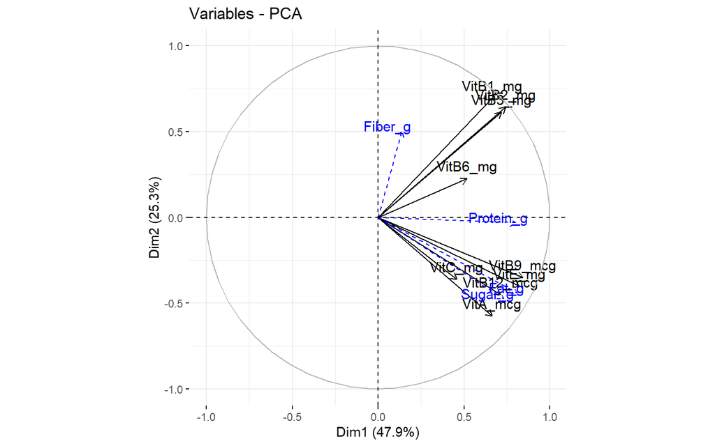

```r
fviz_pca_var(pca.r, axes = c(1,2))
```

Le premiere axe représente 47.9% de l’inertie et l’axe 2 représente 25.3% de l’inertie. On a donc un total de 73.2% d’inertie conservée sur le premier plan factoriel avec les variables ‘Fat_g’, ‘Fiber_g’, ‘Protein_g’ et ‘Sugar_g’ en variables supplémentaires. L’axe 1, dans ce cas ci, conserve moins d’inertie que dans le cas traité en partie 1, mais l’axe 2, quant à lui, conserve une inertie supérieure à celle traité dans la partie 2.

Sur le plan factoriel (3,4) :

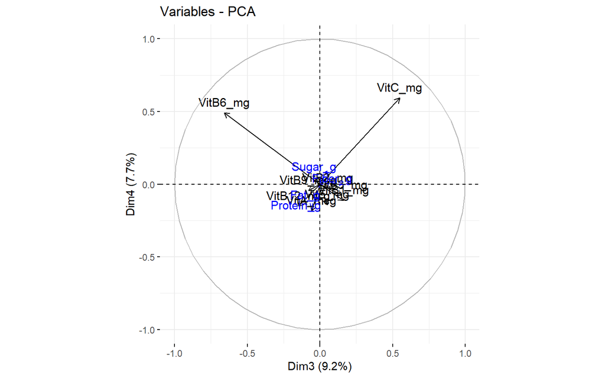

```r
fviz_pca_var(pca.r, axes = c(3,4))
```

Dans le cas où on rajoute ‘Sugar_g’, ‘Protein_g’, ‘Fat_g’ et ‘Fiber_g’ en variables supplémentaires (cas ci-dessus), on observe que l’inertie conservée par les deux dimensions est plus grande que dans le cas de la partie 1. De plus, on observe aussi une légère rotation des vecteurs des variables dans le sens antihoraire. Ensuite, la variable ‘Fiber_g’ est beaucoup moins bien représenté ici que sur le cas d’avant. Ce plan factoriel est quand même peu représentatif de l’inertie, tout comme dans la partie 1. Iil convient donc de rester concentré sur le plan factoriel (1,2).

## Analyse des individus

Le tableau des coordonnées factorielles des points individus est le suivant :

```r
plats <- c(237,218,216,144,141,140,149,340,125)
ind <- get_pca_ind(pca.r)
ind$coord[plats,1:2]
```

```
##         Dim.1       Dim.2
## 237 5.7231287 -2.40911120
## 218 5.3963832 -3.42072586
## 216 7.6033046 -3.38037758
## 144 6.9553901  7.55403572
## 141 1.3260340 -0.09009481
## 140 0.8343946  2.03610038
## 149 0.1279626  0.58026838
## 340 1.1210207  2.64563572
## 125 4.9408480  6.47986433
```

Encore une fois, les plats 218 et 216 se retrouveront à un endroit similaire du graphique. Cela est dû à leur composition en vitamines. Ils restent toujours opposés au plat 144 par rapport à l’axe 2 dû à une composition en vitamines B1, B2 et B3 importante dans ce plat.

La variance des abscisses des points est la même formule vu dans la parite 1. Nous ne calculerons ici cette variance que d’une seule manière.

```r
var_psi1 <- pca.r$eig[1,1] ; var_psi1
```

```
## [1] 4.314862
```

```r
var_psi2 <- pca.r$eig[2,1] ; var_psi2
```

```
## [1] 2.275454
```

Cela correspond bien à la valeur observée sur l’éboulis des valeurs propres.

Nous regardons maintenant les 20 plats contribuant le plus à l’axe 1 :

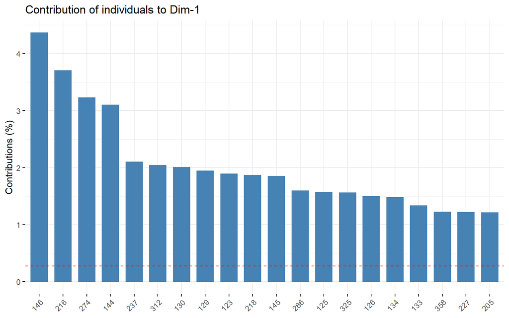

```r
fviz_contrib(pca.r,choice="ind",axes=1, top=20)
```

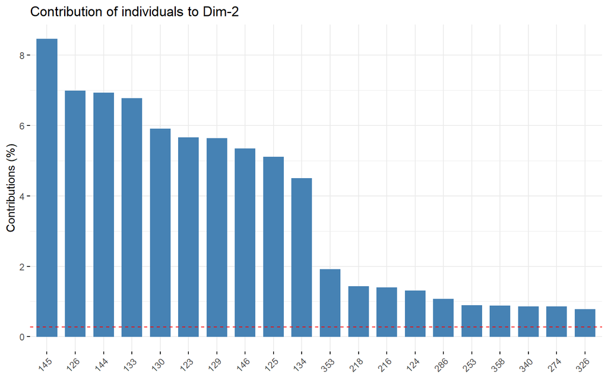

```r
fviz_contrib(pca.r,choice="ind",axes=2, top=20)
```

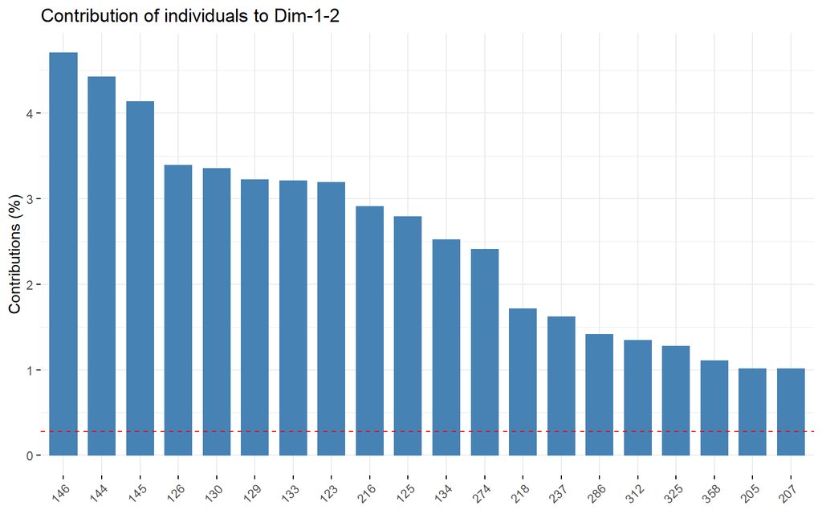

```r
fviz_contrib(pca.r,choice="ind",axes=c(1,2), top=20)
```

On observe que certains plats sont moins bien représentés dans ce cas-ci et d’autres sont mieux représentés. Cela est dû à leurs différentes compositions en vitamines et compositions nutritionnelles. Ici, la composante nutritionnelle étant mise de côté, les plats constitués de graisses, sucres, fibres ou encore protéines seront moins bien représentés alors que ceux n’ayant qu’une faible composition nutritionnelle seront mieux représentées.

Maintenant, nous nous intéressons à la position des plats sur les différents plan factoriels que nous avons vu précédemment.

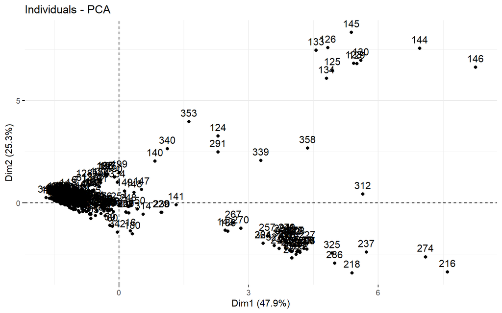

```r
fviz_pca_ind(pca.r, axes = c(1,2))
```

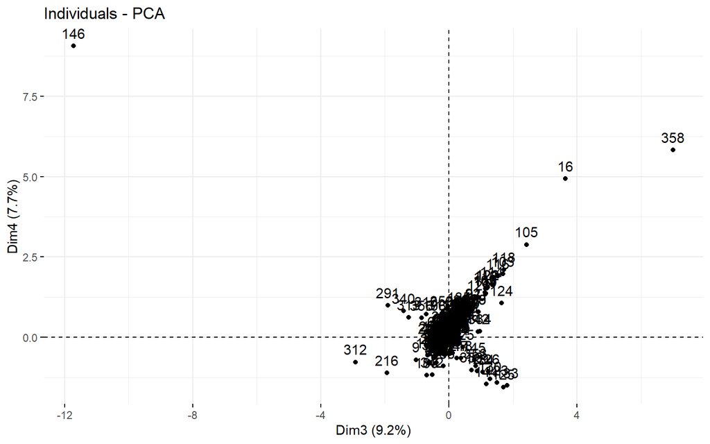

```r
fviz_pca_ind(pca.r, axes = c(3,4))
```

Les représentations restent similaires, que ce soit dans cette partie ou dans la première. On peut observer 4 groupes distincts, dont 2 n’ayant pas d’effets particuliers sur les axes 1 et 2 (ceux à proximité de 0, tels que le 69 ou encore le 147). Le groupe présent sur la partie supérieure droite du graphique aura tendance à avoir une proportion de vitamines B1, B2 et B3 plus importante que ceux dans la partie inférieure droite. Ceux dans la partie inférieure droite auront une composition en vitamines, autres que les 3 citées précédemment, plus importante que celles présentes dnas la partie supérieure droite.

# 5. Inactivation de certains plats

## a) Filtration des données

On va filtrer les données pour sélectionner tous les plats ayant une coordonnée : • Supérieure à 3 sur le premier axe • Négative sur le deuxième axe.

```r
indiv <- get_pca_ind(pca.r)
# indiv$coord
liste_plats= c()
for(plat in 1:362){
  if(indiv$coord[plat,1]>3 & indiv$coord[plat,2]<0){
    liste_plats <- rbind(liste_plats,plat)
  }
}
liste_plats
```

```
##      [,1]
## plat  203
## plat  205
## plat  207
## plat  208
## plat  211
## plat  214
## plat  216
## plat  218
## plat  223
## plat  224
## plat  227
## plat  228
## plat  233
## plat  237
## plat  240
## plat  241
## plat  246
## plat  249
## plat  251
## plat  253
## plat  257
## plat  260
## plat  261
## plat  272
## plat  274
## plat  277
## plat  279
## plat  283
## plat  286
## plat  294
## plat  296
## plat  315
## plat  316
## plat  317
## plat  320
## plat  321
## plat  322
## plat  323
## plat  324
## plat  325
## plat  326
## plat  327
## plat  331
```

## b) Nouvel ensemble de plats par rapport à la base complète des 362 plats

On ne conserve que les plats présent dans la partie inférieure droite dont la coordonnées sur l’axe 1 est strictement supérieure à 3. On y retrouvera donc les plats qu’on voit sur le graphique des individus qui ont une forte contribution sur la dimension 1 tels que le plat 216 ou 218. Ainsi, en appliquant ce filtre, on perdra de l’information sur les données.

## c) Interprétation du nouveau plan factoriel (1,2) avec le nouvel ensemble de plats

On reprends le modèle de la question 4 en mettant les plats de la liste `liste_plats` en inactif.

```r
pcafilter <- PCA(data.baby2.comp, scale.unit=TRUE, graph=FALSE, quanti.sup=c(10:13),ind.sup = liste_plats)
pcafilter$eig
```

```
##        eigenvalue percentage of variance cumulative percentage of variance
## comp 1 3.52320149             39.1466832                          39.14668
## comp 2 1.43205792             15.9117546                          55.05844
## comp 3 1.01513859             11.2793177                          66.33776
## comp 4 0.92061692             10.2290769                          76.56683
## comp 5 0.84729626              9.4144028                          85.98124
## comp 6 0.67396316              7.4884795                          93.46971
## comp 7 0.45171871              5.0190968                          98.48881
## comp 8 0.11026763              1.2251959                          99.71401
## comp 9 0.02573933              0.2859925                         100.00000
```

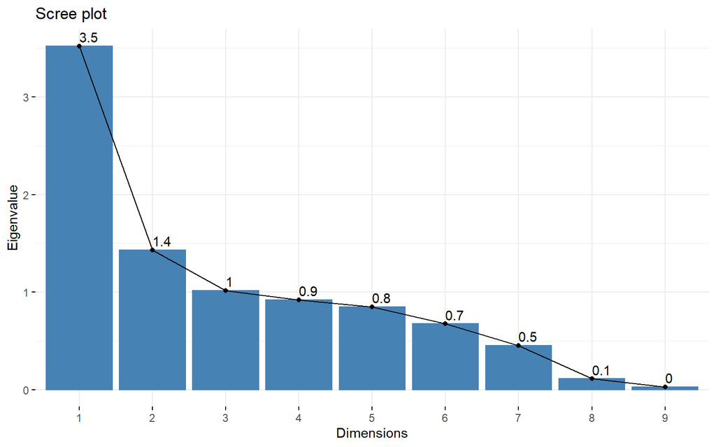

```r
fviz_eig(pcafilter, choice = "eigenvalue", addlabels=TRUE)
```

```r
varf <- get_pca_var(pcafilter)
```

La règle de Kaiser nous dit qu’il faut conserver les 3 premiers axes pour une inertie totale de 66%, car leurs valeurs propres sont supérieurs ou égales à 1. On choisir d’inclure l’axe 4 à cette analyse pour avoir une inertie totale de 76%. Comme on s’y attendait, la dimension 1 perd en pourcentage d’inertie à cause de l’inactivation de ces plats.

Nous allons regarder le premier plan factoriel des variables pour pouvoir ensuite interpréter le placement des individus.

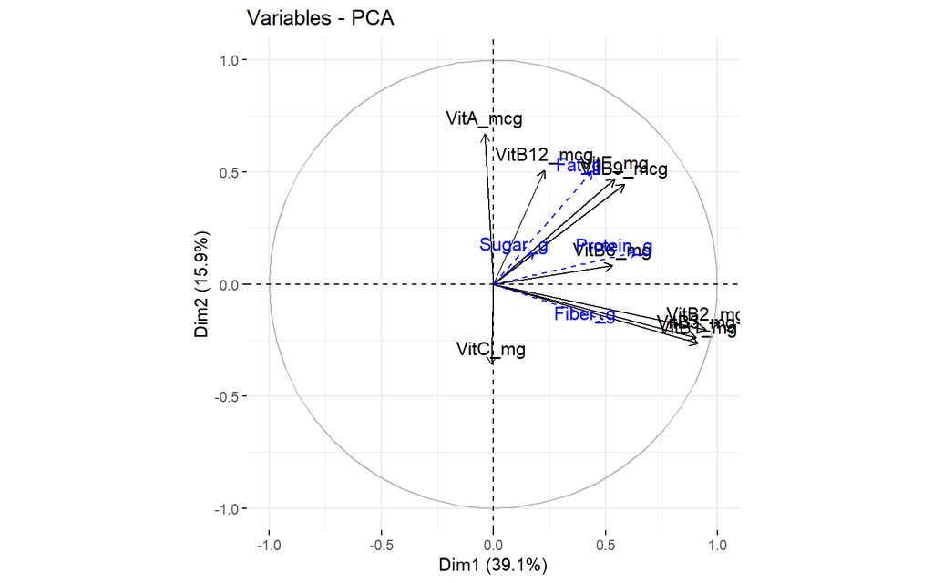

```r
fviz_pca_var(pcafilter, axes = c(1,2))
```

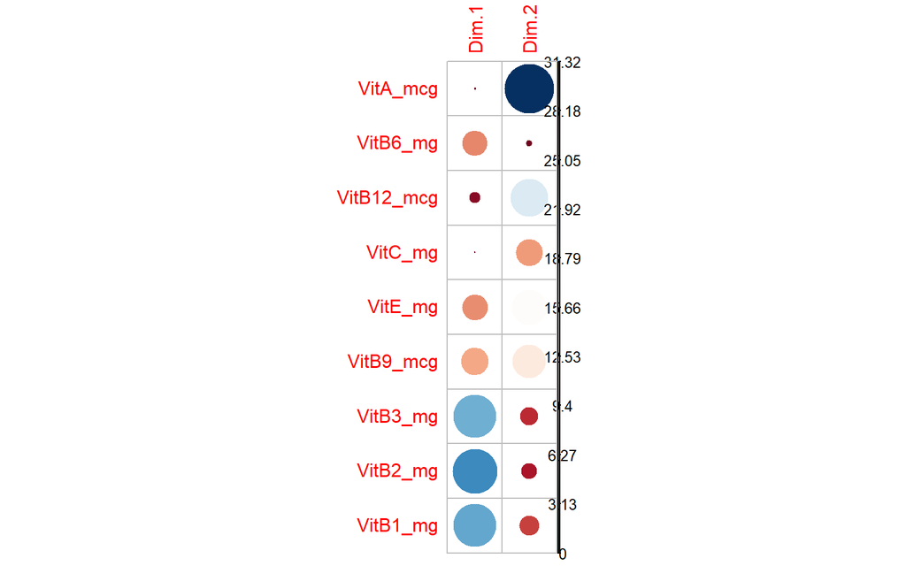

```r
var <- get_pca_var(pcafilter)
corrplot(var$contrib[,1:2], is.corr=FALSE)
```

On ne pourra pas interpreter les variables ‘VitC_mg’ et ‘VitB12_mcg’ car leurs projections ne sont pas satisfaisantes (< 0.5). Par contre, les individus présent en bas à droite auront une forte teneur en ‘VitB1_mg’ , ‘VitB2_mg’, ‘VitB3_mg’, et ceux qui seront dans la partie supérieure auront une composition en vitamines, autres que ces 3 là, importantes. On remarquera que les vecteurs sont opposées par rapport à l’axe 1 par rapport aux graphiques des variables des deux parties précédentes.

Le graphe des individus sur le premier plan factoriel est le suivant :

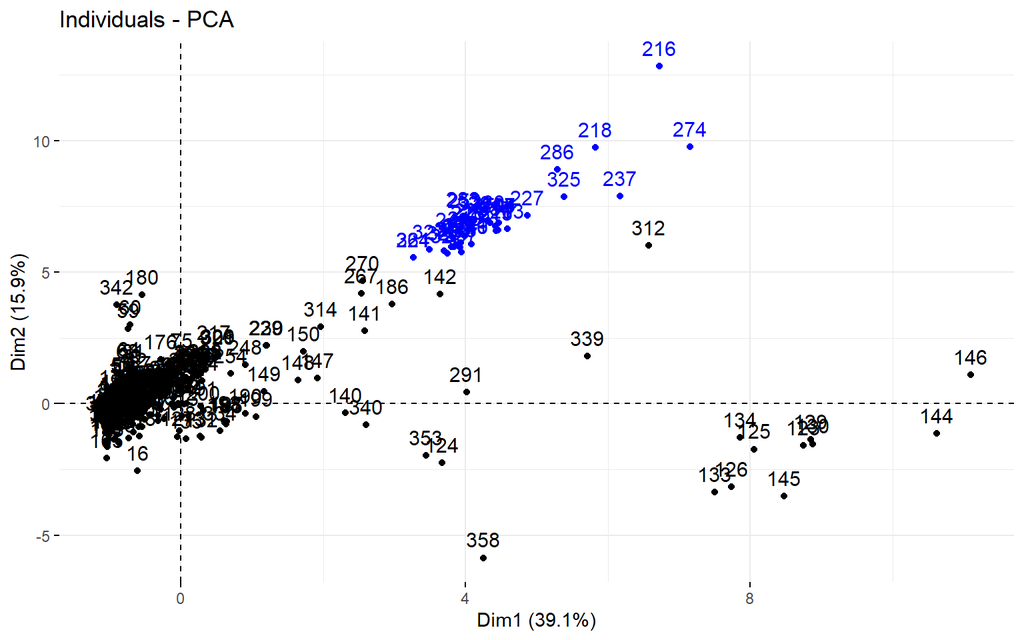

```r
fviz_pca_ind(pcafilter, axes = c(1,2))
```

Ici, certains points sont remarquables. Ils correspondent aux plats ayant la plus grande quantité d’une des vitamines qui construisent ce plan. Par exemple, le plat 216 est le plat avec le plus de vitamine A et qui contient pas mal de vitamine B12 dans notre base de données. Ainsi, ils se retrouvent au plus haut de notre graphique. Nos points bleus sont donc parmi les plats qui contiennent beaucoup de vitamines A et B12.

# Conclusion

Pour conclure, dans ce projet, nous avons utilisé un jeu de donnée contenant des plats pour bébés, avec leur composition nutritionnelle et en vitamines. Nous avons réalisé plusieurs ACP normées, car les variables avaient des unités différentes. Avec le jeu de données complet, nous avons pu identifier deux groupes distincts de vitamines. Certains plats contribuent beaucoup à la construction des dimensions que l’on retient lors de l’ACP. Puis, dans un second temps, nous avons réalisé une ACP en mettant les variables nutritionnelles en supplémentaires (inactif). Les groupes identifiés plus tôt ont été renconnus. On obtient alors des résultats qui sont à peu près semblables à ce qu’on avait avant. Enfin, nous avons rendus inactifs certains plats qui étaient porteurs d’informations pour le premier axe. Cette fois-ci, les résultats de l’ACP sont significativement différents. La première dimension n’est plus portée par les mêmes variables. Le graphe des individus s’en retrouve alors bouleversé.